# Solutions to Applied Predictive Modeling (Kuhn and Johnson, 2013)

Chapter 7 - Exercise 7.2

by Brian Hassett

# Introduction

This exercise uses the data from Friedman (1991)[^1] to explore how a model deals with noise. Data simulated from a number of informative variables is combined with non-informative variables and models are fit to the data. A useful model would be able to detect the signal and successfully identify the informative variables and filter out the noise. MARS, SVM and KNN models are tested.

This solution uses the `tidymodels` package to implement the modeling.

# Exercise Instructions

*Instructions adapted from Kuhn and Johnson (2013)[^2].*

Friedman (1991) introduced several benchmark data sets create by simulation. One of these simulations used the following nonlinear equation to create data:

$$y = 10 sin(\pi x_1 x_2) + 20(x_3 − 0.5)^2 + 10x_4 + 5x_5 + N(0, \sigma^2)$$

where the $x$ values are random variables uniformly distributed between $[0, 1]$ (there are also 5 other non-informative variables created in the simulation). The package `mlbench` contains a function called `mlbench.friedman1` that simulates these data. Tune several models on these data. Which models appear to give the best performance? Does MARS select the informative predictors (those named `X1` to `X5`)?

# Setup

```r
# Load packages
library(caret)
library(tidyverse)
library(tidymodels)
library(patchwork)
library(mlbench)
library(earth)

# Load my functions:
source("/home/brian/R/dir/Util/bh_functions.R")

# Options:
theme_set(theme_bw())
options(digits = 4)
```

# Data

## Training data

Generate the simulated training data:

```r
set.seed(200)
trainingData <- mlbench.friedman1(200, sd = 1)

# We convert the 'x' data from a matrix to a data frame
# One reason is that this will give the columns names.
trainingData$x <- data.frame(trainingData$x)

# Combine the data:
df_train <- cbind(y = trainingData$y, trainingData$x)
```

Plot the training data using `ggplot2` (this is the equivalent of `caret::featurePlot()`):

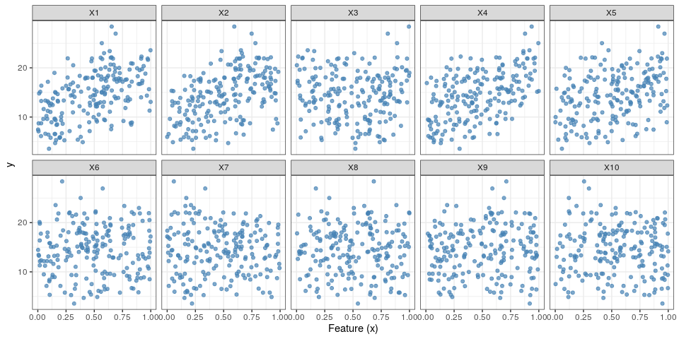

```r
df_train %>%
  pivot_longer(X1:X10, names_to = "sample", values_to = "x") %>%
  mutate(sample = factor(sample, levels = str_c("X", 1:10), ordered = TRUE)) %>%
  ggplot() +
  geom_point(aes(x, y),
             color = "steelblue", alpha = 0.7) +
  facet_wrap(~sample, nrow = 2) +
  labs(x = "Feature (x)", y = "y")
```

## Test data

Generate test data:

```r
# This creates a list with a vector 'y' and a matrix
# of predictors 'x'. Also simulate a large test set to
# estimate the true error rate with good precision:
testData <- mlbench.friedman1(5000, sd = 1)
testData$x <- data.frame(testData$x)

# Combine the data:
df_test <- cbind(y = testData$y, testData$x)
```

# MARS

Fit a variety of MARS models on the simulated data. We are not using cross-validation in this exercise. Rather, we fit the models on the simulated training data and make predictions on the test data. We will be assessing the models performance using both the test error and by inspecting what variables the models deemed the most important.

Create a grid of parameters to use. We are varying the `num_terms` and `prod_degree` parameters:

```r
mars_grid <- expand.grid(num_terms = seq(2,14,by=2), prod_degree = 1:2)
```

## Models specs

Create a list of models, each one with a set of parameters from the grid created above:

```r
mars_mods <- pmap(mars_grid, parsnip::mars)
```

## Fit models

Fit each of the models on the simulated data. (There may be a more compact way of specifying the model parameters as well as the mode and engine in one go. Here I have specified the models and parameters above using `pmap()`, then I set the mode and engine using `map()` before passing it on to `fit()` below):

```r
set.seed(1)
mars_fits <- mars_mods %>%
  map(function(mod) {
    fit <- mod %>%
      set_engine("earth") %>%
      set_mode("regression") %>%
      parsnip::fit(y ~ ., data = df_train) # formula is included here rather than in a separate recipe
  })
```

## Predictions

The test data was simulated above and stored in data frame called `df_test`. Use this data to make predictions:

```r
preds <- mars_fits %>%
  map(~predict(., new_data = df_test))
```

## Plot RMSE

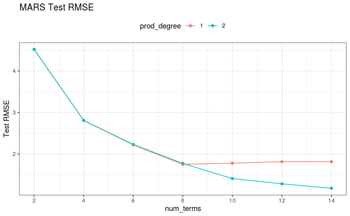

```r
# Extract the test RMSE values:
rmse <- map_dbl(preds, ~RMSE(.x$.pred, df_test$y))

# Combine the RMSE values with the grid of model parameters:
mars_grid_rmse <-
  cbind(mars_grid, rmse) %>%
  mutate(
    prod_degree = factor(prod_degree)
)

# Plot:
mars_grid_rmse %>%
  ggplot(aes(num_terms, rmse, color = prod_degree)) +
  geom_point() +
  geom_line() +
  labs(y = "Test RMSE", title = "MARS Test RMSE") +
  scale_x_continuous(breaks = seq(2, 14, 2)) +
  theme(legend.position = "top")
```

## Best model

Identify the model which gives the lowest test error:

```r
best_params <- mars_grid_rmse %>%
  arrange(rmse) %>%
  head(1)
best_params
```

|  | num_terms | prod_degree | rmse |
| --- | --- | --- | --- |
| 1 | 14 | 2 | 1.172 |

Create a fresh model with the optimal parameters (I’m not sure that this is the optimal way to do this. I may need to revisit and see if there is a better way to inspect the model that has already been fit):

```r
best_mod <- earth(y ~ ., data = df_train,
                  nprune = best_params$num_terms,
                  degree = as.numeric(best_params$prod_degree))
summary(best_mod)
```

```
Call: earth(formula=y~., data=df_train, degree=as.numeric(best_params$prod_degree), nprune=best_params$num_terms)

                                coefficients
(Intercept)                           21.905
h(0.621722-X1)                       -15.726
h(X1-0.621722)                         9.234
h(0.601063-X2)                       -18.254
h(X2-0.601063)                        10.449
h(0.447442-X3)                         9.701
h(X3-0.606015)                        12.675
h(0.734892-X4)                        -9.864
h(X4-0.734892)                        10.298
h(0.850094-X5)                        -5.324
h(0.218266-X1) * h(X2-0.601063)      -55.359
h(X1-0.218266) * h(X2-0.601063)      -29.100
h(X1-0.621722) * h(X2-0.295997)      -26.833
h(0.649253-X1) * h(0.601063-X2)       27.121

Selected 14 of 18 terms, and 5 of 10 predictors (nprune=14)
Termination condition: Reached nk 21
Importance: X1, X4, X2, X5, X3, X6-unused, X7-unused, X8-unused, X9-unused, X10-unused
Number of terms at each degree of interaction: 1 9 4
GCV 1.629    RSS 225.9    GRSq 0.9338    RSq 0.9537
```

This is also clear from the variable importance measures:

```r
varImp(best_mod)
```

|  | Overall |
| --- | --- |
| X1 | 100.00 |
| X4 | 85.13 |
| X2 | 69.22 |
| X5 | 49.28 |
| X3 | 39.95 |

Plot each predictor versus the outcome using `plotmo()` (I’m not yet aware of a way to do these plots using `ggplot2`):

|  | plotmo grid: X1 | X2 | X3 | X4 | X5 | X6 | X7 | X8 | X9 | X10 |
| --- | --- | --- | --- | --- | --- | --- | --- | --- | --- | --- |
|  | 0.5139 | 0.5107 | 0.5373 | 0.4446 | 0.5343 | 0.4976 | 0.4688 | 0.498 | 0.5289 | 0.5359 |

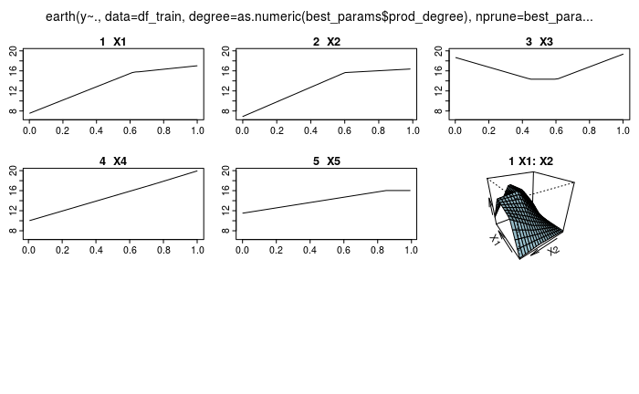

```r
plotmo(best_mod)
```

## Store Test Error

```r
RMSE <- data.frame(
  model = "MARS",
  RMSE = best_params$rmse
)
```

# SVM with Radial Basis Function

Fit a variety of SVM models with radial basis functions on the simulated data.

## Data

Use the same data as above.

## Grid of parameters

Create a grid of parameters to use:

```r
svm_grid <- expand_grid(cost = 2^c(-2, 0, 2, 8),
                        margin = c(0.01, 0.05, 0.1, 0.5),
                        rbf_sigma = kernlab::sigest(y ~ ., data = df_train, frac = .75))
```

## Models specs

Create a list of models, each one with a set of parameters from the grid created above:

```r
svm_mods <- pmap(svm_grid, parsnip::svm_rbf)
```

## Fit models

Fit each of the models on the simulated data. (There may be a more compact way of specifying the model parameters as well as the mode and engine in one go. Here I have specified the models and parameters above using `pmap()`, then I set the mode and engine using `map()` before passing it on to `fit()` below):

```r
set.seed(1)
svm_fits <- svm_mods %>%
  map(function(mod) {
    fit <- mod %>%
      set_engine("kernlab") %>%
      set_mode("regression") %>%
      parsnip::fit(y ~ ., data = df_train) # formula is included here rather than in a separate recipe
  })
```

## Predictions

The test data was simulated above and stored in data frame called `df_test`. Use this data to make predictions:

```r
preds <- svm_fits %>%
  map(~predict(., new_data = df_test))
```

## Plot RMSE

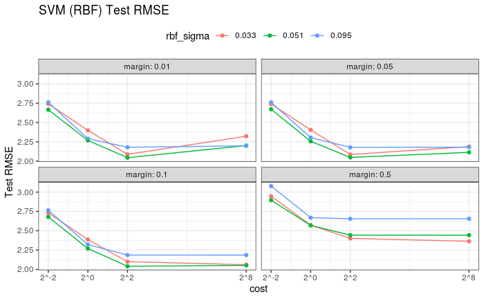

```r
# Extract the test RMSE values:
rmse <- map_dbl(preds, ~RMSE(.x$.pred, df_test$y))

# Combine the RMSE values with the grid of model parameters:
svm_grid_rmse <- cbind(svm_grid, rmse)

# Plot:
svm_grid_rmse %>%
  mutate(rbf_sigma = factor(round(rbf_sigma, 3)),
         margin = factor(margin)) %>%
  ggplot(aes(cost, rmse, color = rbf_sigma)) +
  geom_point() +
  geom_line() +
  facet_wrap(~margin, labeller = label_both) +
  labs(y = "Test RMSE", title = "SVM (RBF) Test RMSE") +
  scale_x_continuous(trans = "log2", breaks = 2^c(-2, 0, 2, 8), labels = str_c("2^", c(-2, 0, 2, 8))) +
 # scale_y_continuous(breaks = seq(2.1, 2.6, 0.1)) +
  theme(legend.position = "top")
```

## Best model

Identify the model which gives the lowest test error:

```r
best_params <- svm_grid_rmse %>%
  arrange(rmse) %>%
  head(1)
best_params
```

|  | cost | margin | rbf_sigma | rmse |
| --- | --- | --- | --- | --- |
| 1 | 4 | 0.1 | 0.05136 | 2.041 |

## Store Test Error

```r
RMSE <- rbind(
  RMSE,
  c(model = "SVM (RBF)", RMSE = best_params$rmse)
)
```

# SVM with Polynomial Kernel

Fit a variety of SVM models with polynomial kernels on the simulated data.

## Data

Use the same data as above.

## Grid of parameters

Create a grid of parameters to use:

```r
svm_grid <- expand_grid(cost = 2^c(-2, 0, 2, 8),
                        degree = 1:2)
```

## Models specs

Create a list of models, each one with a set of parameters from the grid created above:

```r
svm_mods <- pmap(svm_grid, parsnip::svm_poly)
```

## Fit models

Fit each of the models on the simulated data. (There may be a more compact way of specifying the model parameters as well as the mode and engine in one go. Here I have specified the models and parameters above using `pmap()`, then I set the mode and engine using `map()` before passing it on to `fit()` below):

```r
set.seed(1)
svm_fits <- svm_mods %>%
  map(function(mod) {
    fit <- mod %>%
      set_engine("kernlab") %>%
      set_mode("regression") %>%
      parsnip::fit(y ~ ., data = df_train) # formula is included here rather than in a separate recipe
  })
```

## Predictions

The test data was simulated above and stored in data frame called `df_test`. Use this data to make predictions:

```r
preds <- svm_fits %>%
  map(~predict(., new_data = df_test))
```

## Plot RMSE

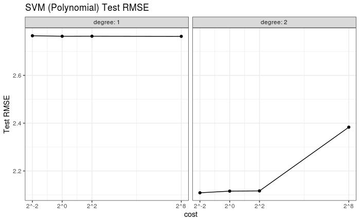

```r
# Extract the test RMSE values:
rmse <- map_dbl(preds, ~RMSE(.x$.pred, df_test$y))

# Combine the RMSE values with the grid of model parameters:
svm_grid_rmse <- cbind(svm_grid, rmse)

# Plot:
svm_grid_rmse %>%
  mutate(degree = factor(degree)) %>%
  ggplot(aes(cost, rmse)) +
  geom_point() +
  geom_line() +
  facet_wrap(~degree, labeller = label_both) +
  labs(y = "Test RMSE", title = "SVM (Polynomial) Test RMSE") +
  scale_x_continuous(trans = "log2", breaks = 2^c(-2, 0, 2, 8), labels = str_c("2^", c(-2, 0, 2, 8))) +
  theme(legend.position = "top")
```

## Best model

Identify the model which gives the lowest test error:

```r
best_params <- svm_grid_rmse %>%
  arrange(rmse) %>%
  head(1)
best_params
```

|  | cost | degree | rmse |
| --- | --- | --- | --- |
| 1 | 0.25 | 2 | 2.109 |

## Store Test Error

```r
RMSE <- rbind(
  RMSE,
  c(model = "SVM (Poly)", RMSE = best_params$rmse)
)
```

# KNN

Fit a variety of KNN models on the simulated data.

## Data

Use the same data as above.

## Grid of parameters

Create a grid of parameters to use:

```r
knn_grid <- expand_grid(neighbors = c(1:4, seq(5, 50, 5)))
```

## Models specs

Create a list of models, each one with a set of parameters from the grid created above:

```r
knn_mods <- pmap(knn_grid, parsnip::nearest_neighbor)
```

## Fit models

Fit each of the models on the simulated data. (There may be a more compact way of specifying the model parameters as well as the mode and engine in one go. Here I have specified the models and parameters above using `pmap()`, then I set the mode and engine using `map()` before passing it on to `fit()` below):

```r
set.seed(1)
knn_fits <- knn_mods %>%
  map(function(mod) {
    fit <- mod %>%
      set_engine("kknn") %>%
      set_mode("regression") %>%
      parsnip::fit(y ~ ., data = df_train) # formula is included here rather than in a separate recipe
  })
```

## Predictions

The test data was simulated above and stored in data frame called `df_test`. Use this data to make predictions:

```r
preds <- knn_fits %>%
  map(~predict(., new_data = df_test))
```

## Plot RMSE

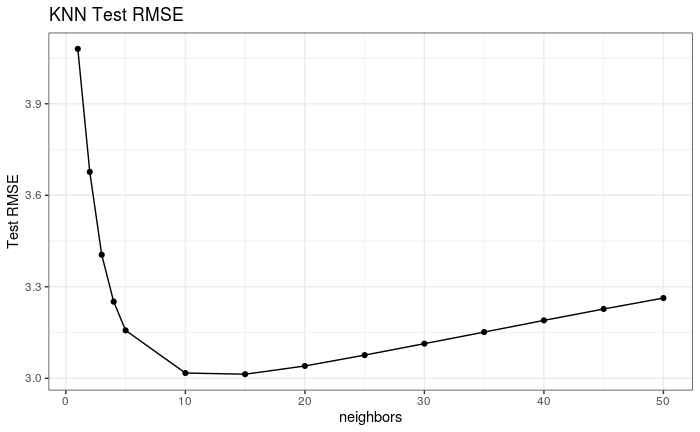

```r
# Extract the test RMSE values:
rmse <- map_dbl(preds, ~RMSE(.x$.pred, df_test$y))

# Combine the RMSE values with the grid of model parameters:
knn_grid_rmse <- cbind(knn_grid, rmse)

# Plot:
knn_grid_rmse %>%
  ggplot(aes(neighbors, rmse)) +
  geom_point() +
  geom_line() +
  labs(y = "Test RMSE", title = "KNN Test RMSE")
```

## Best model

Identify the model which gives the lowest test error:

```r
best_params <- knn_grid_rmse %>%
  arrange(rmse) %>%
  head(1)
best_params
```

|  | neighbors | rmse |
| --- | --- | --- |
| 1 | 15 | 3.013 |

## Store Test Error

```r
RMSE <- rbind(
  RMSE,
  c(model = "KNN", RMSE = best_params$rmse)
)
```

# Inspect Test Error

As well as identifying the five informative variables, the MARS model also had the lowest test error:

```r
RMSE %>%
  mutate(RMSE = round(as.numeric(RMSE), 3)) %>%
  arrange(RMSE)
```

| model | RMSE |
| --- | --- |
| MARS | 1.172 |
| SVM (RBF) | 2.041 |
| SVM (Poly) | 2.109 |
| KNN | 3.013 |

[^1]: Friedman J (1991). “Multivariate Adaptive Regression Splines.” The Annals of Statistics, **19**(1), 1–141.
[^2]: Kuhn M, Johnson K (2013). *Applied Predictive Modeling*. Springer.